# APM1205 Formative Assessment 2

Linear Models: Simple Linear Least-Squares Regression

Submitted by: Kristine Arllaine Daileg

# Part 1 – Understanding the Dataset

## A. Identify the Variables

The **predictor variable (X)** is **TV**, which represents TV advertising expenditure.

The **response variable (Y)** is **Sales**, which represents product sales.

## B. Describe the Variables

`TV` represents TV advertising expenditure for each market, measured in thousands of dollars.

`Sales` represents product sales for each market, measured in thousands of units.

Although the dataset also contains Radio and Newspaper advertising expenditure, this assessment focuses only on TV as the predictor and Sales as the response.

## C. Research Question

**Can TV advertising expenditure be used to predict Sales?**

This analysis investigates whether there is a linear relationship between TV advertising expenditure and Sales.

# Part 2 – Exploratory Data Analysis

## A. Inspect the Dataset

First, the Advertising dataset is loaded into R.

```r
advertising <- read.csv("Advertising.csv")

head(advertising)
```

```
##   X    TV Radio Newspaper Sales
## 1 1 230.1  37.8      69.2  22.1
## 2 2  44.5  39.3      45.1  10.4
## 3 3  17.2  45.9      69.3   9.3
## 4 4 151.5  41.3      58.5  18.5
## 5 5 180.8  10.8      58.4  12.9
## 6 6   8.7  48.9      75.0   7.2
```

```r
dim(advertising)
```

```
## [1] 200   5
```

```r
summary(advertising)
```

```
##        X                TV             Radio          Newspaper
##  Min.   :  1.00   Min.   :  0.70   Min.   : 0.000   Min.   :  0.30
##  1st Qu.: 50.75   1st Qu.: 74.38   1st Qu.: 9.975   1st Qu.: 12.75
##  Median :100.50   Median :149.75   Median :22.900   Median : 25.75
##  Mean   :100.50   Mean   :147.04   Mean   :23.264   Mean   : 30.55
##  3rd Qu.:150.25   3rd Qu.:218.82   3rd Qu.:36.525   3rd Qu.: 45.10
##  Max.   :200.00   Max.   :296.40   Max.   :49.600   Max.   :114.00
##      Sales
##  Min.   : 1.60
##  1st Qu.:10.38
##  Median :12.90
##  Mean   :14.02
##  3rd Qu.:17.40
##  Max.   :27.00
```

## B. Scatterplot

The following scatterplot shows the relationship between TV advertising expenditure and Sales.

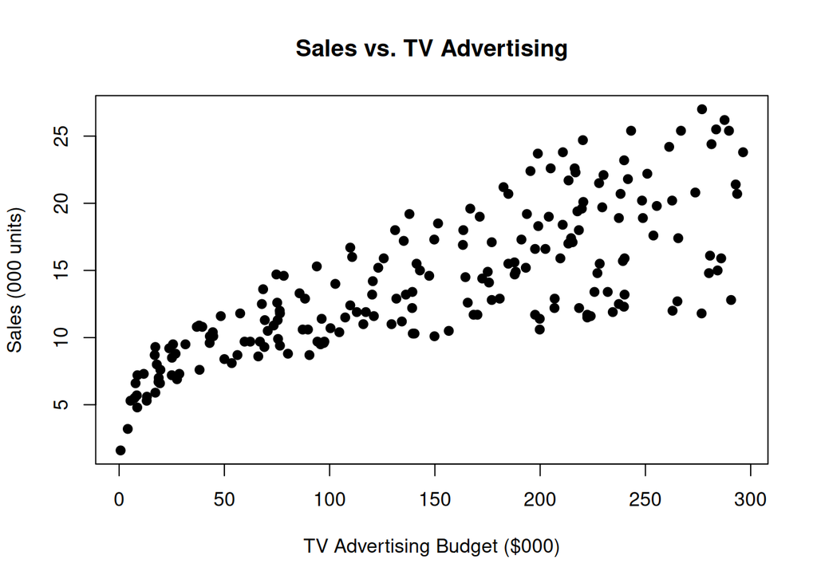

```r
plot(advertising$TV,
     advertising$Sales,
     main = "Sales vs. TV Advertising",
     xlab = "TV Advertising Budget ($000)",
     ylab = "Sales (000 units)",
     pch = 19)
```

## C. Interpretation of the Scatterplot

The scatterplot shows a positive relationship between TV advertising expenditure and Sales. In general, markets with higher TV advertising budgets tend to have higher Sales. The points follow an upward pattern that appears to be approximately linear, although there is still some variation around the trend. Overall, TV advertising appears to be useful for predicting Sales.

# Part 3 – Simple Linear Regression Model

The simple linear regression model is

$$Y = A + BX + E$$

where $Y$ is the response variable, $X$ is the predictor variable, $A$ is the intercept, $B$ is the slope, and $E$ represents the error.

For this analysis:

$$Sales = A + B(TV) + E$$

## A. Fit the Regression Model

```r
model <- lm(Sales ~ TV, data = advertising)

summary(model)
```

```
##
## Call:
## lm(formula = Sales ~ TV, data = advertising)
##
## Residuals:
##     Min      1Q  Median      3Q     Max
## -8.3860 -1.9545 -0.1913  2.0671  7.2124
##
## Coefficients:
##             Estimate Std. Error t value Pr(>|t|)
## (Intercept) 7.032594   0.457843   15.36   <2e-16 ***
## TV          0.047537   0.002691   17.67   <2e-16 ***
## ---
## Signif. codes:  0 '***' 0.001 '**' 0.01 '*' 0.05 '.' 0.1 ' ' 1
##
## Residual standard error: 3.259 on 198 degrees of freedom
## Multiple R-squared:  0.6119, Adjusted R-squared:  0.6099
## F-statistic: 312.1 on 1 and 198 DF,  p-value: < 2.2e-16
```

## B. Regression Coefficients

```r
coef(model)
```

```
## (Intercept)          TV
##  7.03259355  0.04753664
```

The intercept is approximately **7.032594**.

The slope is approximately **0.047537**.

## C. Regression Equation

The fitted regression equation is

$$\widehat{Sales} = 7.032594 + 0.047537(TV)$$

Therefore, the predicted Sales can be calculated using:

$$\boxed{\widehat{Sales} = 7.032594 + 0.047537(TV)}$$

## D. Interpretation of the Intercept

The intercept is approximately **7.032594**.

This means that when TV advertising expenditure is 0 thousand dollars, the model predicts Sales of approximately **7.033 thousand units**.

## E. Interpretation of the Slope

The slope is approximately **0.047537**.

Since TV advertising is measured in thousands of dollars and Sales is measured in thousands of units, for every additional **$1,000 spent on TV advertising**, predicted Sales increase by approximately **0.047537 thousand units**, on average.

This is approximately **47.537 additional units of Sales** for every additional $1,000 spent on TV advertising.

# Part 4 – Least-Squares and Residual Analysis

A residual is the difference between the observed value and its predicted value:

$$E_i = Y_i - \widehat{Y}_i$$

The least-squares regression line is selected by minimizing the sum of the squared residuals.

## A. Calculate Fitted Values

```r
advertising$Predicted_Sales <- fitted(model)

head(advertising)
```

```
##   X    TV Radio Newspaper Sales Predicted_Sales
## 1 1 230.1  37.8      69.2  22.1       17.970775
## 2 2  44.5  39.3      45.1  10.4        9.147974
## 3 3  17.2  45.9      69.3   9.3        7.850224
## 4 4 151.5  41.3      58.5  18.5       14.234395
## 5 5 180.8  10.8      58.4  12.9       15.627218
## 6 6   8.7  48.9      75.0   7.2        7.446162
```

The fitted value represents the Sales predicted by the regression model for each observation.

## B. Calculate Residuals

```r
advertising$Residual <- residuals(model)

head(advertising)
```

```
##   X    TV Radio Newspaper Sales Predicted_Sales   Residual
## 1 1 230.1  37.8      69.2  22.1       17.970775  4.1292255
## 2 2  44.5  39.3      45.1  10.4        9.147974  1.2520260
## 3 3  17.2  45.9      69.3   9.3        7.850224  1.4497762
## 4 4 151.5  41.3      58.5  18.5       14.234395  4.2656054
## 5 5 180.8  10.8      58.4  12.9       15.627218 -2.7272181
## 6 6   8.7  48.9      75.0   7.2        7.446162 -0.2461623
```

The residual represents the difference between the actual Sales and predicted Sales.

## C. First 10 Observations

```r
first_10 <- head(
  advertising[, c("TV",
                  "Sales",
                  "Predicted_Sales",
                  "Residual")],
  10
)

knitr::kable(
  first_10,
  digits = 4,
  col.names = c(
    "TV",
    "Actual Sales",
    "Predicted Sales",
    "Residual"
  ),
  caption = "First 10 Observations with Fitted Values and Residuals"
)
```

First 10 Observations with Fitted Values and Residuals

| TV | Actual Sales | Predicted Sales | Residual |
| --- | --- | --- | --- |
| 230.1 | 22.1 | 17.9708 | 4.1292 |
| 44.5 | 10.4 | 9.1480 | 1.2520 |
| 17.2 | 9.3 | 7.8502 | 1.4498 |
| 151.5 | 18.5 | 14.2344 | 4.2656 |
| 180.8 | 12.9 | 15.6272 | -2.7272 |
| 8.7 | 7.2 | 7.4462 | -0.2462 |
| 57.5 | 11.8 | 9.7660 | 2.0340 |
| 120.2 | 13.2 | 12.7465 | 0.4535 |
| 8.6 | 4.8 | 7.4414 | -2.6414 |
| 199.8 | 10.6 | 16.5304 | -5.9304 |

## D. Interpret One Residual

The first observation is used as an example.

```r
first_actual <- advertising$Sales[1]
first_predicted <- advertising$Predicted_Sales[1]
first_residual <- advertising$Residual[1]

first_actual
```

```
## [1] 22.1
```

```r
first_predicted
```

```
## [1] 17.97077
```

```r
first_residual
```

```
## [1] 4.129225
```

For the first observation, the actual Sales are **22.1 thousand units** and the predicted Sales are approximately **17.9708 thousand units**.

The residual is:

$$E_1 = Y_1 - \widehat{Y}_1$$

$$E_1 =
22.1
-
17.9708
=
4.1292$$

The residual is positive, meaning that the actual Sales are higher than the Sales predicted by the regression model for this observation.

# Part 5 – Residual Plot

A residual plot is useful for checking whether there is a pattern in the residuals.

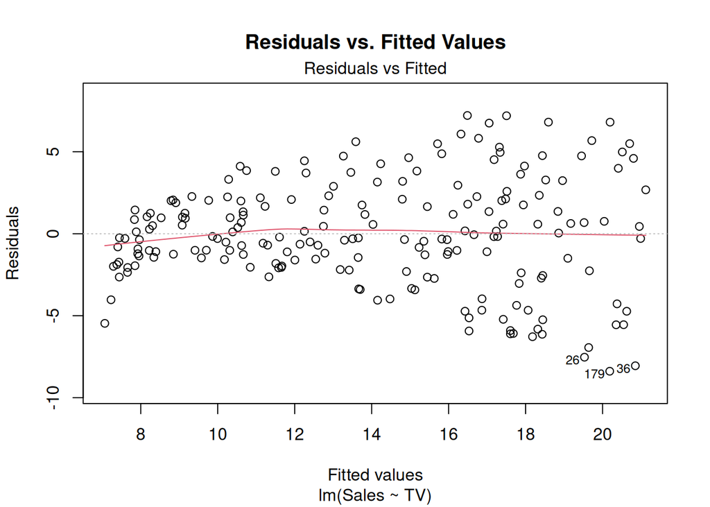

```r
plot(model,
     which = 1,
     main = "Residuals vs. Fitted Values")
```

## Interpretation of the Residual Plot

The residuals are generally distributed around zero. There does not appear to be a very strong systematic pattern in the residuals. However, there is still some variation in the residuals, including a few observations with relatively large residuals. Overall, the residual plot does not indicate a severe problem with using a simple linear regression model for these data.

# Part 6 – Residual Standard Error

The residual standard error is calculated using

$$S_e =
\sqrt{
\frac{\sum E_i^2}{n-2}
}$$

The residual standard error can be obtained in R using:

```r
summary(model)$sigma
```

```
## [1] 3.258656
```

The residual standard error is approximately:

$$S_e = \text{3.258656}$$

Therefore, the residual standard error is approximately **3.259 thousand units**.

This indicates the typical size of the prediction error when using TV advertising expenditure to predict Sales.

# Part 7 – Sums of Squares

The total sum of squares is

$$TSS = \sum(Y_i-\bar{Y})^2$$

The residual sum of squares is

$$RSS = \sum(Y_i-\widehat{Y}_i)^2$$

The regression sum of squares is

$$RegSS = TSS-RSS$$

## A. Calculate TSS, RSS, and RegSS

```r
y <- advertising$Sales
yhat <- fitted(model)

TSS <- sum((y - mean(y))^2)

RSS <- sum((y - yhat)^2)

RegSS <- TSS - RSS

TSS
```

```
## [1] 5417.149
```

```r
RSS
```

```
## [1] 2102.531
```

```r
RegSS
```

```
## [1] 3314.618
```

## B. Results

```r
sums_of_squares <- data.frame(
  Measure = c(
    "TSS",
    "RSS",
    "RegSS"
  ),
  Value = c(
    TSS,
    RSS,
    RegSS
  )
)

knitr::kable(
  sums_of_squares,
  digits = 5,
  caption = "Sums of Squares"
)
```

Sums of Squares

| Measure | Value |
| --- | --- |
| TSS | 5417.149 |
| RSS | 2102.531 |
| RegSS | 3314.618 |

The calculated values are approximately:

$$TSS = 5417.14875$$

$$RSS = 2102.53058$$

$$RegSS = 3314.61817$$

The relationship between the sums of squares is:

$$TSS = RegSS + RSS$$

```r
RegSS + RSS
```

```
## [1] 5417.149
```

Using the calculated values:

$$3314.61817 + 2102.53058
=
5417.14875$$

Therefore,

$$TSS = RegSS + RSS$$

The **TSS** represents the total variation in Sales. The **RegSS** represents the variation explained by TV advertising through the regression model. The **RSS** represents the variation that remains unexplained by the model.

# Part 8 – Correlation and r²

## A. Correlation

The correlation coefficient is calculated using:

```r
r <- cor(
  advertising$TV,
  advertising$Sales
)

r
```

```
## [1] 0.7822244
```

The correlation coefficient is approximately:

$$r = 0.782224$$

The positive value indicates a positive linear relationship between TV advertising expenditure and Sales. Since the value is relatively close to 1, the relationship can be described as fairly strong.

## B. Coefficient of Determination

The coefficient of determination is calculated as:

$$r^2$$

```r
r_squared <- r^2

r_squared
```

```
## [1] 0.6118751
```

```r
summary(model)$r.squared
```

```
## [1] 0.6118751
```

The coefficient of determination is approximately:

$$r^2 = 0.611875$$

or

$$61.19\%$$

Therefore, approximately **61.19% of the variation in Sales is explained by the linear relationship between TV advertising expenditure and Sales**.

The remaining approximately **38.81%** is not explained by this simple regression model and may be associated with other factors.

# Part 9 – Overall Conclusion

The analysis suggests that TV advertising expenditure can be used to predict Sales to a useful extent. The scatterplot shows a positive and approximately linear relationship between TV advertising and Sales. The fitted regression equation is $\widehat{Sales} = 7.032594 + 0.047537(TV)$, showing that predicted Sales increase as TV advertising expenditure increases. For every additional $1,000 spent on TV advertising, predicted Sales increase by approximately 0.047537 thousand units, or about 47.537 units, on average. The residual standard error is approximately 3.259 thousand units, indicating that there is still some prediction error. The correlation coefficient of approximately 0.7822 indicates a fairly strong positive linear relationship. The $r^2$ value of approximately 61.19% means that about 61.19% of the variation in Sales is explained by TV advertising expenditure. Overall, TV advertising is a useful predictor of Sales, although other variables could be considered to improve the model.

# Complete R Code Used

The complete R code used for the analysis is provided below.

```r
# ==========================================
# APM1205 Formative Assessment 2
# Simple Linear Least-Squares Regression
# ==========================================

# Load the Advertising dataset
advertising <- read.csv("Advertising.csv")

# Inspect the dataset
head(advertising)
```

```
##   X    TV Radio Newspaper Sales
## 1 1 230.1  37.8      69.2  22.1
## 2 2  44.5  39.3      45.1  10.4
## 3 3  17.2  45.9      69.3   9.3
## 4 4 151.5  41.3      58.5  18.5
## 5 5 180.8  10.8      58.4  12.9
## 6 6   8.7  48.9      75.0   7.2
```

```r
dim(advertising)
```

```
## [1] 200   5
```

```r
summary(advertising)
```

```
##        X                TV             Radio          Newspaper
##  Min.   :  1.00   Min.   :  0.70   Min.   : 0.000   Min.   :  0.30
##  1st Qu.: 50.75   1st Qu.: 74.38   1st Qu.: 9.975   1st Qu.: 12.75
##  Median :100.50   Median :149.75   Median :22.900   Median : 25.75
##  Mean   :100.50   Mean   :147.04   Mean   :23.264   Mean   : 30.55
##  3rd Qu.:150.25   3rd Qu.:218.82   3rd Qu.:36.525   3rd Qu.: 45.10
##  Max.   :200.00   Max.   :296.40   Max.   :49.600   Max.   :114.00
##      Sales
##  Min.   : 1.60
##  1st Qu.:10.38
##  Median :12.90
##  Mean   :14.02
##  3rd Qu.:17.40
##  Max.   :27.00
```

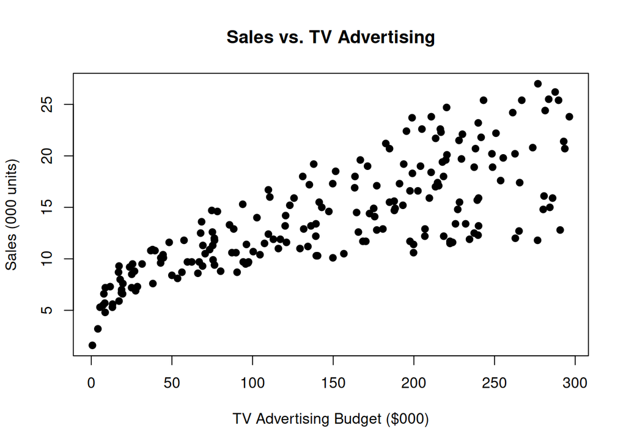

```r
# Create scatterplot
plot(advertising$TV,
     advertising$Sales,
     main = "Sales vs. TV Advertising",
     xlab = "TV Advertising Budget ($000)",
     ylab = "Sales (000 units)",
     pch = 19)
```

```r
# Fit simple linear regression model
model <- lm(Sales ~ TV, data = advertising)

# Display regression results
summary(model)
```

```
##
## Call:
## lm(formula = Sales ~ TV, data = advertising)
##
## Residuals:
##     Min      1Q  Median      3Q     Max
## -8.3860 -1.9545 -0.1913  2.0671  7.2124
##
## Coefficients:
##             Estimate Std. Error t value Pr(>|t|)
## (Intercept) 7.032594   0.457843   15.36   <2e-16 ***
## TV          0.047537   0.002691   17.67   <2e-16 ***
## ---
## Signif. codes:  0 '***' 0.001 '**' 0.01 '*' 0.05 '.' 0.1 ' ' 1
##
## Residual standard error: 3.259 on 198 degrees of freedom
## Multiple R-squared:  0.6119, Adjusted R-squared:  0.6099
## F-statistic: 312.1 on 1 and 198 DF,  p-value: < 2.2e-16
```

```r
# Display regression coefficients
coef(model)
```

```
## (Intercept)          TV
##  7.03259355  0.04753664
```

```r
# Calculate fitted values
advertising$Predicted_Sales <- fitted(model)

# Calculate residuals
advertising$Residual <- residuals(model)

# Display first 10 observations
head(
  advertising[, c("TV",
                  "Sales",
                  "Predicted_Sales",
                  "Residual")],
  10
)
```

```
##       TV Sales Predicted_Sales   Residual
## 1  230.1  22.1       17.970775  4.1292255
## 2   44.5  10.4        9.147974  1.2520260
## 3   17.2   9.3        7.850224  1.4497762
## 4  151.5  18.5       14.234395  4.2656054
## 5  180.8  12.9       15.627218 -2.7272181
## 6    8.7   7.2        7.446162 -0.2461623
## 7   57.5  11.8        9.765950  2.0340496
## 8  120.2  13.2       12.746498  0.4535023
## 9    8.6   4.8        7.441409 -2.6414087
## 10 199.8  10.6       16.530414 -5.9304143
```

```r
# Residual standard error
summary(model)$sigma
```

```
## [1] 3.258656
```

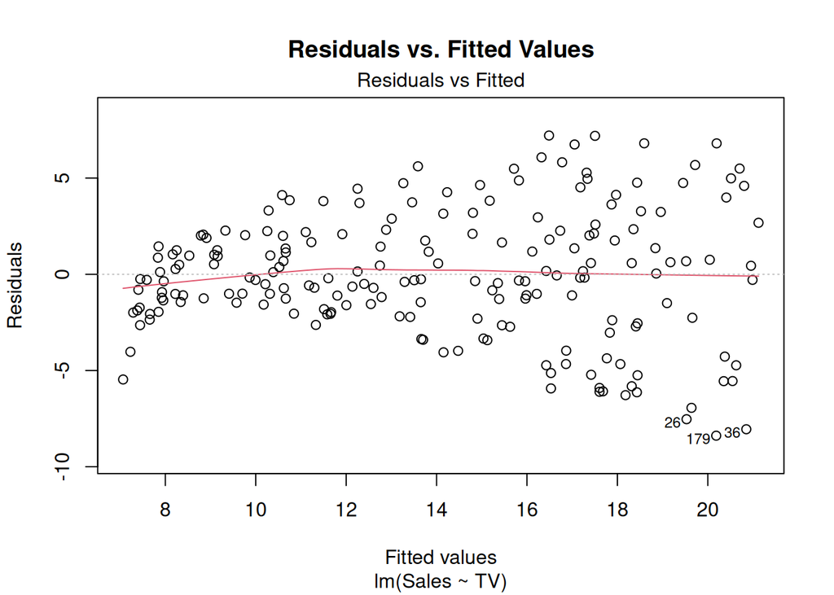

```r
# Create residual plot
plot(model,
     which = 1,
     main = "Residuals vs. Fitted Values")
```

```r
# Calculate correlation
r <- cor(
  advertising$TV,
  advertising$Sales
)

r
```

```
## [1] 0.7822244
```

```r
# Calculate r-squared
r_squared <- r^2

r_squared
```

```
## [1] 0.6118751
```

```r
# Calculate sums of squares
y <- advertising$Sales
yhat <- fitted(model)

TSS <- sum((y - mean(y))^2)

RSS <- sum((y - yhat)^2)

RegSS <- TSS - RSS

TSS
```

```
## [1] 5417.149
```

```r
RSS
```

```
## [1] 2102.531
```

```r
RegSS
```

```
## [1] 3314.618
```

```r
# Verify TSS = RegSS + RSS
RegSS + RSS
```

```
## [1] 5417.149
```

# Dataset Source

The dataset used in this assessment is the **Advertising** dataset specified in the assessment instructions.

Dataset source:

https://www.statlearning.com/s/Advertising.csv